# Workshop Week 11

Author

Affiliation

STAT5003

School of Mathematics and Statistics

# 1 Learning Outcomes

**Learning Outcomes**

This week, we’ll explore Monte Carlo methods for integration and use simulation to help us understand complex real-world phenomena.

# 2 Loading Packages

At the start of your R workshop, load all necessary packages to ensure a smooth session. Here’s an example:

```r
library(tidyverse)  # Data science packages
library(ggplot2)    # Data visualization
library(ggthemes)   # Inclusive ggplot themes
library(here)       # File paths
```

# 3 Evaluate an integral

Integrate the following function using the Monte Carlo integration method on the interval [0,3] on $x$. Compare the Monte Carlo estimate of the integral to the value calculated using the `integrate()` function in R $g(x) = x^3 \sin\left(\frac{x+3.4}{2}\right)$.

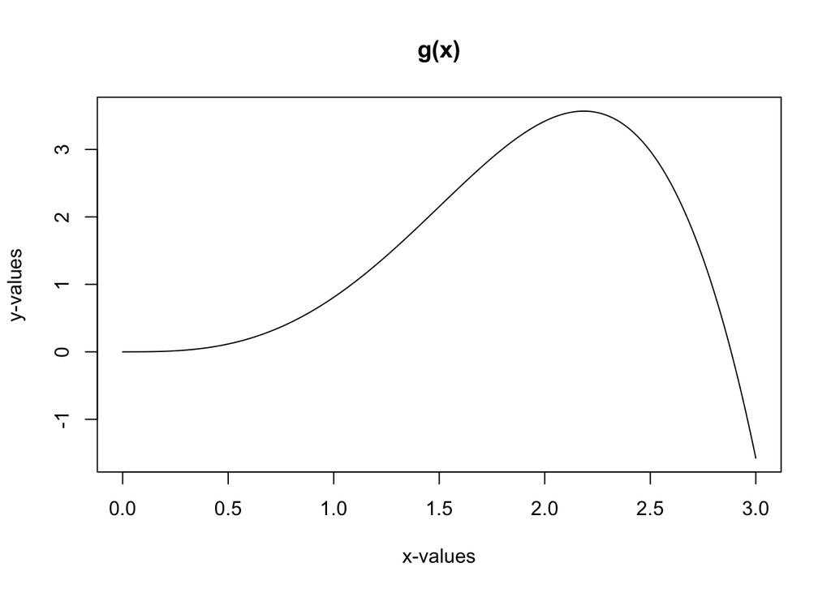

```r
# plot data and create the true relationship line
s <- function(x) { x^3 * sin((x + 3.4) / 2) }
x.plot <- seq(0, 3, length.out = 1000)
y.plot <- s(x.plot)
plot(x.plot, y.plot, xlab = "x-values", ylab = "y-values", main = "g(x)", type = "l")
```

Our Monte Carlo estimate of the integral is 4.63.

```r
set.seed(5003)
# Randomly sample from the interval we want to integrate
n <- 50000
x <- runif(n, min = 0, max = 3)
sx <- s(x)
# Remember to multiply by the length of the interval from 0 to 3.
ans.mc <- 3 * mean(sx)
ans.mc
```

```
[1] 4.626804
```

Whereas our `integrate()` returns 4.65.

```r
# use the inbuilt integrate function
ans.quad <- integrate(s, 0, 3)
ans.quad
```

```
4.652802 with absolute error < 5.4e-14
```

# 4 Exotic financial option simulation

In finance, there are basic options like call and put options—but there are also more complex ones called **exotic options**. One example is the **knock-out call option**.

**A knock-out call option** is a type of option where there’s a specific price level called the **knock-out barrier**. If the stock price ever reaches or goes above this barrier before the option expires, the option becomes worthless, even if the final stock price would have led to a profit.

To understand this better, let’s first recall the two standard types of options:

- European option: You can exercise (use) the option **only at the expiry date**.
- American option: You can exercise the option **any time before or on the expiry date**.

In our case, we’re working with **a European-style knock-out option**. This means:

- The payoff is calculated only at the expiry date.

However, the entire history of the stock price from the purchase to the expiry matters.

- If the stock price ever hits the knock-out level before expiry, you get nothing.
- If it doesn’t hit the knock-out barrier, you get the normal payoff: max($S_T - K, 0)$ where $S_T$ is the stock price at expiry, and $K$ is the strike price.

**Stock price simulation**

Write code to simulate the prices of stocks using the Geometric Brownian motion type model discussed in lecture.

$$\begin{align*}
dS = S (\mu dT + \sigma \sqrt{dT} \mathcal N)
\end{align*}$$

- $\mu$ is the growth rate of the stock price
- $\sigma$ is known as the volatility
  - Think of this as the variance of the stock price
- $\mathcal N$ is a standard normal random variable
- $dT$ is one unit of time. Assume the increment in time is daily over a year period ($dT = 1/365$)

The function should have parameters for: the number of days in the simulation, the initial stock price ($S_0$), drift term ($\mu$), and volatility ($\sigma$).

Using your function, produce a plot of 5 different simulations of stock prices over a 90 day period assuming $S_0 = \$100$, $\mu = 0.05$ but the volatility changes from $\sigma = 0.1, 0.25, 0.5, 0.75, 1$.

```r
set.seed(5003)

stock.sim <- function(ndays, S0, mu, sigma) {
    <write your function here>
}


sigmas <- c(0.1, 0.25, 0.5, 0.75, 1)
<write your simulation code here>
<write your plotting code here>
```

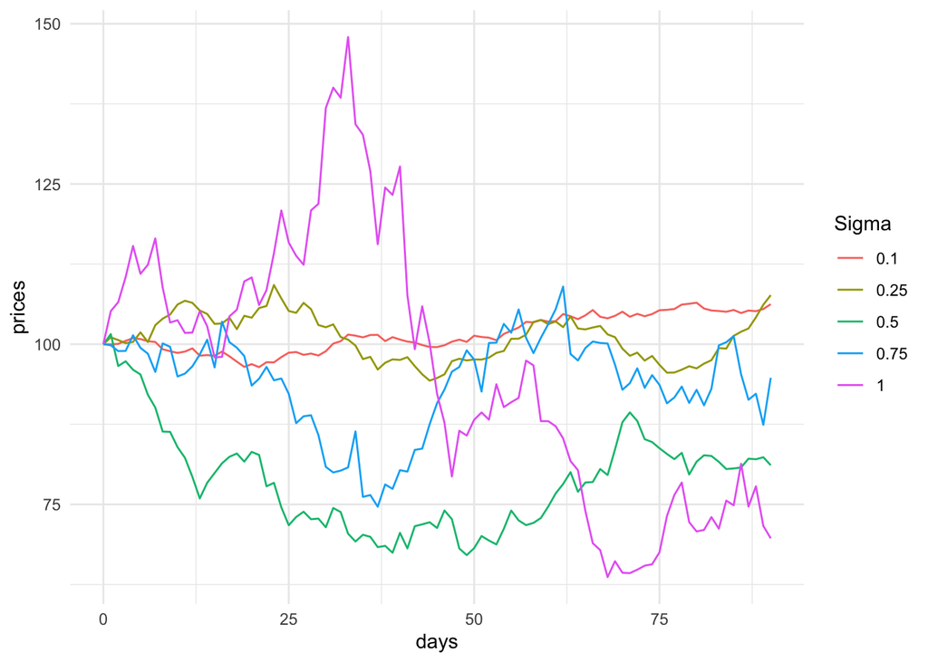

```r
set.seed(5003)

stock.sim <- function(ndays = 90, S0 = 100, mu = 0.05, sigma = 0.5) {
    N <- rnorm(ndays)
    S <- S0
    dT <- 1 / 365
    Ssim <- S
    for (i in 1:ndays) {
        dS <- S * (mu * dT + sigma * sqrt(dT) * N[i])
        S <- S + dS
        Ssim <- c(Ssim, S)
    }
    Ssim
}

sigmas <- c(0.1, 0.25, 0.5, 0.75, 1)
simulated.prices = list()

for(idx in 1:length(sigmas)) {
  simulated.prices[[idx]] = stock.sim(sigma = sigmas[idx])
}

simulated.prices = unlist(simulated.prices)

price.dat <- data.frame(days = rep(0:90, 5),
                        prices = simulated.prices,
                        Sigma = factor(rep(sigmas, each = 91)))
ggplot(price.dat) +
    theme_minimal() +
    geom_line(aes(x = days, y = prices, group = Sigma, colour = Sigma))
```

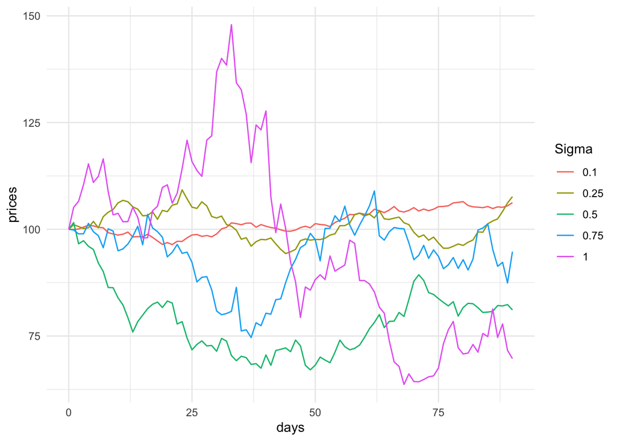

```r
## alternative way of writing it, there are many other ways to write this function

set.seed(5003)

stock_sim <- function(ndays = 90, S0 = 100, mu = 0.05, sigma = 0.5) {
  dT <- 1 / 365
  shocks <- rnorm(ndays)
  prices <- numeric(ndays + 1)
  prices[1] <- S0

  for (i in 1:ndays) {
    prices[i + 1] <- prices[i] + prices[i] * (mu * dT + sigma * sqrt(dT) * shocks[i])
  }
  return(prices)
}

sigmas <- c(0.1, 0.25, 0.5, 0.75, 1)
simulated_prices <- list()

for (i in 1:length(sigmas)) {
  simulated_prices[[i]] <- stock_sim(sigma = sigmas[i])
}

price_dat <- data.frame(
  days = rep(0:90, times = length(sigmas)),
  prices = unlist(simulated_prices),
  Sigma = factor(rep(sigmas, each = 91))
)


ggplot(price.dat) +
    theme_minimal() +
    geom_line(aes(x = days, y = prices, group = Sigma, colour = Sigma))
```

**Compute the exotic option pay-offs**

Write another function that takes a stock price vector (stock prices over a time period) and determines the pay-off of this exotic knockout option. The function will need to have three arguments as input, the historical stock prices to be evaluated, the option strike price and the knockout level.

For example, suppose a knockout option had a strike of $105, knock out level of $130. Then this function would need to check that the entire stock price vector doesn’t exceed $130 (if it does the payoff is worthless, i.e. zero) and otherwise give the payoff as the maximum of the stock price at expiry minus the strike price and zero.

```r
knockout.payoff <- function(stock.prices, strike.price, knockout) {
  <write your function code here>
}
```

```r
knockout.payoff <- function(stock.prices, strike.price, knockout) {
  if(any(stock.prices > knockout)) {
    return(0)
  } else {
    return(max(tail(stock.prices, 1) - strike.price, 0))
  }
}
```

**Conduct Monte carlo simulation of pay-offs**

Using the pricing strategy discussed in lecture, that is, assuming the fair price is the average expected payoff of the option, compute the appropriate price for a knockout exotic option that expires in 90 day with a strike price of $105 and a knockout level of $130. Assume that the associated stock prices have the calibration of $S_0 = \$100$, $\mu = 0.05$, and $\sigma = 0.5$.

1. Modify the code below, which calculates the payoff of a vanilla European call option, such that it computes the payoff for the exotic option. **You may refer to the lecture slides.**

```r
set.seed(5003)

# Initialising variables
n.iterations <- 5000
S0 <- 100
mu <- 0.05
sigma <- 0.5
ndays <- 90

# Write out your function for vanilla option payoffs
vanilla.payoff <- function() {
  <write your function code here>
}

<Write your Monte Carlo stimulation code here>
```

2. Determine how much cheaper is this knock-out call option compared to a vanilla call option.
3. Create a plot to make that comparison.

```r
set.seed(5003)

n.iterations <- 5000
S0 <- 100
mu <- 0.05
sigma <- 0.5
ndays <- 90

vanilla.payoff <- function(stock.prices, strike.price) {
  max(tail(stock.prices, 1) - strike.price, 0)
}

simulated.prices <- matrix(NA, nrow = 91, ncol = n.iterations)

for(i in 1:n.iterations){
  simulated.prices[,i] <- stock_sim(ndays = ndays, S0 = S0, mu = mu, sigma = sigma)
}


exotic.pay.offs = c()
vanilla.pay.offs = c()

for(i in 1:n.iterations){
  exotic.pay.offs[i] <- knockout.payoff(simulated.prices[,i], 105, 130)
  vanilla.pay.offs[i] <- vanilla.payoff(simulated.prices[,i], 105)
}
```

The exotic option has a much lower average pay-off of 1.52

```r
mean(exotic.pay.offs)
```

```
[1] 1.520006
```

Whereas the vanilla pay-off has an average pay-off of around 8.724

```r
mean(vanilla.pay.offs)
```

```
[1] 8.723601
```

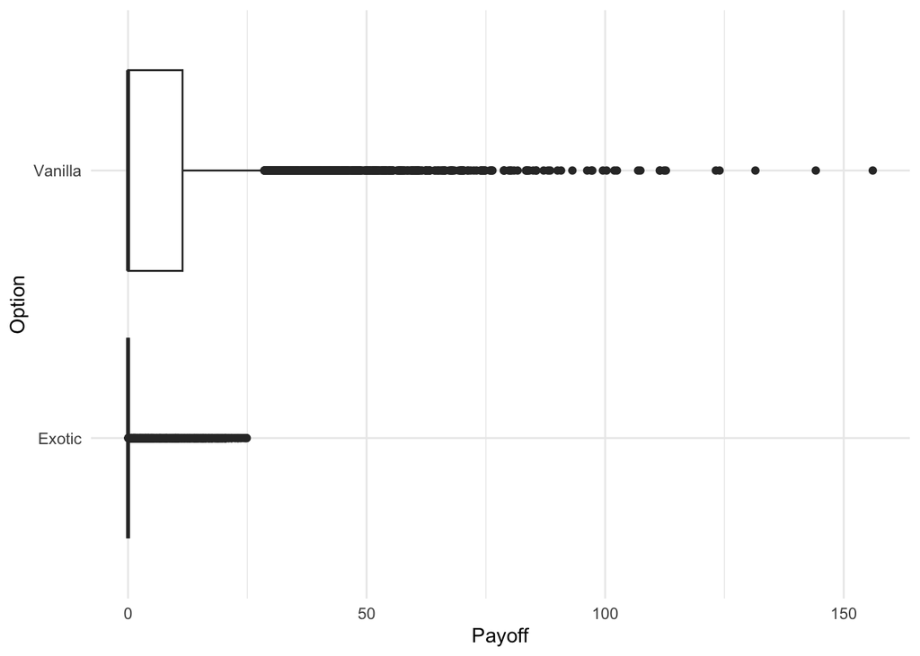

```r
dat <- data.frame(Option = rep(c("Vanilla", "Exotic"), each = n.iterations),
                  Payoff = c(vanilla.pay.offs, exotic.pay.offs))
ggplot(data = dat) + theme_minimal() +
  geom_boxplot(aes(x = Payoff, y = Option))
```